# Searching in Biological Databases (Task 2)

Alex-Alex-Helena

7 oktober, 2021

## Introduction

The purpose of this task is to play around with querying different types of biological databases using R. In the following, some questions will be answered using queries.

### Question 1:

Retrieve the genome of a cat via its *scientific name* or *taxonomic identifier from NCBI Taxonomy*. Then read the file.

This information will be retrieved using the library `biomartr`. The documentation can be found [here](https://rdrr.io/cran/biomartr/man/getGenome.html)

### Answer 1:

```r
# Retrieval of the genome into a file. THIS CODE TAKES SOME TIME!
file.path <- getGenome(db = "refseq", organism = "Felis catus")
```

```
#> Starting genome retrieval of 'Felis catus' from refseq ...
```

```
#> It seems that this is the first time you run this command for refseq.
```

```
#> Thus, 'assembly_summary.txt' files for all kingdoms will be retrieved from refseq.
```

```
#> Don't worry this has to be done only once if you don't restart your R session.
```

[output not shown]

```
#> Completed!
```

```
#> Now continue with species download ...
```

```
#> File _ncbi_downloads/genomes/Felis_catus_genomic_refseq.fna.gz exists already. Thus, download has been skipped.
```

```
#> The genome of 'Felis_catus' has been downloaded to '_ncbi_downloads/genomes' and has been named 'Felis_catus_genomic_refseq.fna.gz'.
```

```r
# or

#file.path <- getGenome(db = "refseq", organism = "9685")
```

```r
# Display the genome.
(cat.genome <- read_genome(file.path, format = "fasta"))
```

```
#> DNAStringSet object of length 37:
#>          width seq                                          names
#>  [1] 242100913 ATCAGGAGATCTAGATGCCTG...AAGCACCTTCATGTTCCCAA NC_018723.3 Felis...
#>  [2]     46965 CTTTCTTTTTCTAAAATTCTC...CACCAATTATATGGGACTAG NW_019365239.1 Fe...
#>  [3]     58068 AAATCGTGACACATGCTACAT...GCCTCCTGGGCCTTCTCAGC NW_019365240.1 Fe...
#>  [4]     50743 AGTTATAGTAATCTTCCTAGG...CCTGCCTTCCTTTTCTTTTC NW_019365241.1 Fe...
#>  [5]     22574 CATGATTTAGTGAAAACGTAA...TTCTATTTATCACATTTGTT NW_019365242.1 Fe...
#>  ...       ... ...
#> [33]     61658 TCTCCATCAGTCCCTGTGGAG...ACTGATATTTAAAGAAGAGT NW_019365269.1 Fe...
#> [34]     37620 AGAGCTTACTTAAAAAAAAAT...GGAGATCCACTTGGTTGCAA NW_019365270.1 Fe...
#> [35]     51987 GTCAACCGTCTCCAAAAAAAG...TAGTTCAAACGGTCCAGTCT NW_019365271.1 Fe...
#> [36]     41842 ATTTCCTAAGCGAGGTTACCA...AGGGAAAAGCATGAGCGCGA NW_019365272.1 Fe...
#> [37]   1157532 GAGGCAGCGCCGACTCTGAGC...GTATTTTCCCTGAATGGCTG NC_018725.3 Felis...
```

### Question 2:

Find the allele names in the Applied Biosystem identifiler allelic ladder (from the `seqinr` library)

### Answer 2:

The simple solution is just to use

```r
df <- data(identifiler)
```

Could also make a histogram of alleles per locus (an example found in the [documentation](https://cran.r-project.org/web/packages/seqinr/seqinr.pdf) of `seqinr`)

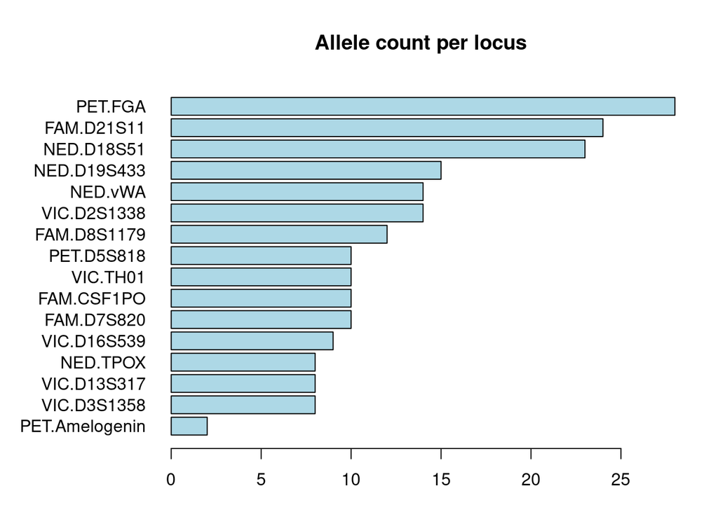

```r
op <- par(no.readonly = TRUE) # Used to reset settings later.
par(mar = c(3,8,4,2)+0.1)
allcount <- unlist(lapply(identifiler, function(x) lapply(x, length)))
barplot(allcount[order(allcount)], horiz = TRUE, las = 1,
main = "Allele count per locus", col = "lightblue")
```

```r
par(op) # Reset the changed margin.
```

### Question 3:

We have the [Uniprot](https://www.uniprot.org/) code of a human transcription factor: Q01196. We must (a) identify the name of the protein; and (b) find molecular pathways where this protein is participating in both KEGG and REACTOME and compare them.

### Answer 3:

1. identify the name of the protein.

```r
#Let's convert the uniprot code to the name of the protein:
prot<-c("Q01196")
ConvertID(prot, ID_from = "ACC+ID" , ID_to = "GENEWIKI_ID", directorypath = NULL)
```

[output not shown]

The protein is named RUNX1.

2. find molecular pathways where this protein is participating, in both KEGG and REACTOME and compare them;

First, we will search in KEGG.

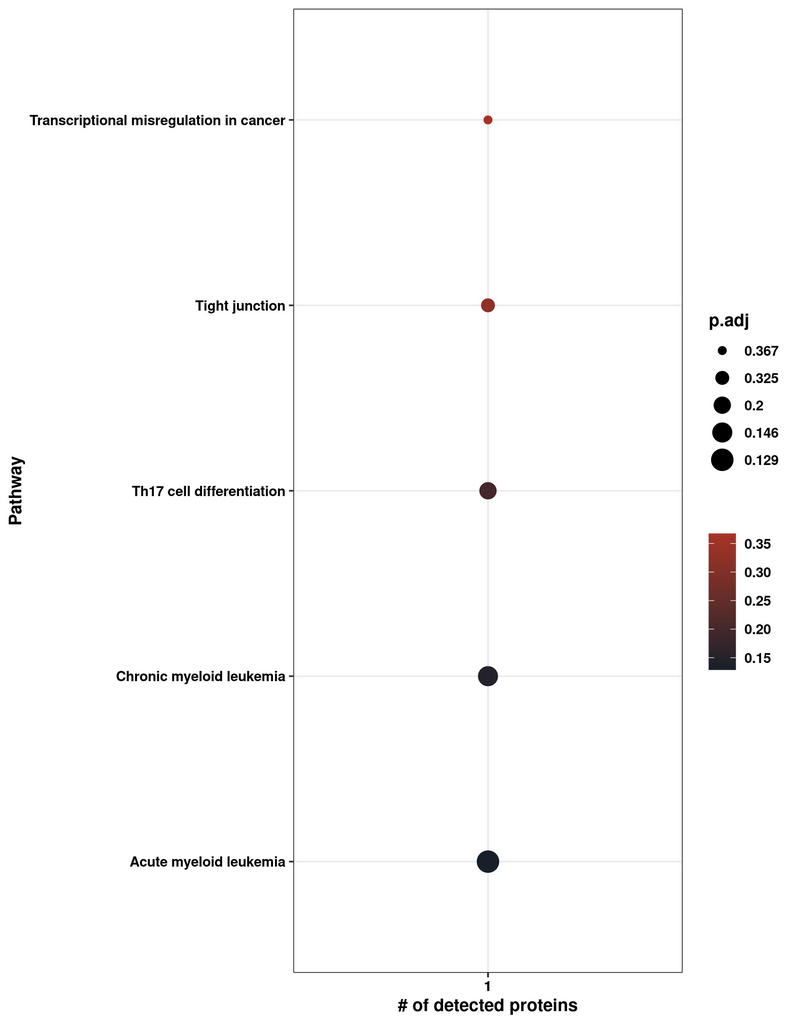

```r
prot<-c("Q01196")
#First, we look in KEGG database. We set the p-value at 0.75, to obtain a higher number of processes.
Enrichment.KEGG(prot,OS="hsapiens",p_value=0.75,directorypath=".") # Saving the image and displaying in markdown instead.
```

RUNX1 seems to be participating in the following molecular pathways: transcriptional misregulation in cancer, tight junction, th17 cell differentiation, and specially in both chronic and acute myeloid leukemia.

Now, we will search in REACTOME.

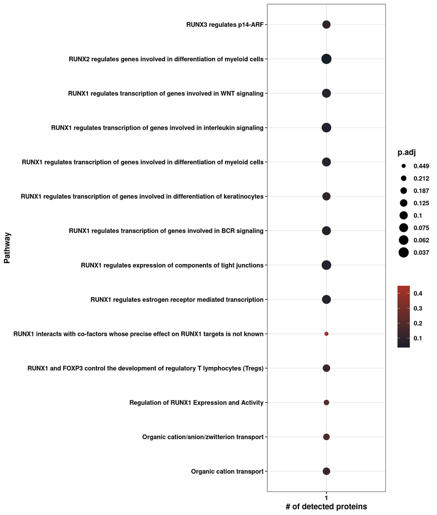

```r
#First, we look in KEGG database. We set the p-value at 0.75, to obtain a higher number of processes.
Enrichment.REAC(prot,OS="hsapiens",p_value=0.75,directorypath=".") # Saving the image and displaying in markdown instead.
```

It can be observed that REACTOME includes much more RUNX1-related pathways than KEGG database. Pathways included in REACTOME appear to be more specific and give us more information about the molecular process. RUNX1 is particularly contributing in cell differentation-related pathways, in some signallings, but also in pathways associated to inflammation. KEGG pathways are general cellular processes, even whole diseases (AML).